# ¶ Introduction to Statistical Computing: Assignment 1: Lesson on Data & Data Structures ¶

AGENDA: Manipulating data objects; using the built-in functions, doing numerical calculations, and basic plots; reinforcing core probabilistic ideas.

#### INSTRUCTIONS:

These directions presume you are reading the **RMarkdown file** and **not** the output file you will use the RMarkdown to create. There will be important differences between the document you eventually produce and the RMarkdown document you use to create that document!

- Type your answers on the space provided under each problem.
- You can embed code in an **R code chunk**.
- Code chunks begin with a line of the form

  ````
  ```{r}
  ````

- Code chunks end with a line of the form

  ````
  ```
  ````

- Below (lines 12-14 in the *RMarkdown document*) is an example:

  ```r
  summary(cars)
  ```

  ```
  ##      speed           dist
  ##  Min.   : 4.0   Min.   :  2.00
  ##  1st Qu.:12.0   1st Qu.: 26.00
  ##  Median :15.0   Median : 36.00
  ##  Mean   :15.4   Mean   : 42.98
  ##  3rd Qu.:19.0   3rd Qu.: 56.00
  ##  Max.   :25.0   Max.   :120.00
  ```

- Before you move to the next step, highlight or move the cursor to the end of the individual R command and click on **Run**. Do this for all R commands.
- After you are done click the **Knit HTML**, **Knit PDF** button (upper left window). A document will be generated that includes both content as well as the output of any embedded R code chunks within the document.
- Go to File –> Save. Name your file.
- Upload the file by using the link provided on Canvas.

## Background

The exponential distribution is defined by its cumulative distribution function

$$F(x) = 1-e^{-\lambda x}$$

The R function `rexp` generates random variables with an exponential distribution.

```
rexp(n=10, rate=5)
```

produces 10 exponentially-distributed numbers with rate ($\lambda$) of 5. If the second argument is omitted, the default rate is 1; this is the ``standard exponential distribution’’.

## Part I

##### Problem 1. (10 points)

Generate 200 random values from the standard exponential distribution and store them in a vector `exp.draws.1`. Find the mean and standard deviation of `exp.draws.1`.

##### Solution

Type your answer here

```r
exp.draws.1 = rexp(n=200, rate=1)
mean(exp.draws.1)
```

```
## [1] 0.9951018
```

```r
sd(exp.draws.1)
```

```
## [1] 1.098228
```

##### Problem 2. (10 points)

Repeat, but change the rate to 0.1, 0.5, 5 and 10, storing the results in vectors called `exp.draws.0.1`, `exp.draws.0.5`, `exp.draws.5` and `exp.draws.10`.

##### Solution

Type your answer here

```r
exp.draws.0.1 = rexp(n = 200, rate = 0.1)
exp.draws.0.5 = rexp(n = 200, rate = 0.5)
exp.draws.5 = rexp(n = 200, rate = 5)
exp.draws.10 = rexp(n = 200, rate = 10)
mean(exp.draws.0.1)
```

```
## [1] 8.998588
```

```r
sd(exp.draws.0.1)
```

```
## [1] 9.04872
```

```r
mean(exp.draws.0.5)
```

```
## [1] 2.474898
```

```r
sd(exp.draws.0.5)
```

```
## [1] 2.396493
```

```r
mean(exp.draws.5)
```

```
## [1] 0.2001032
```

```r
sd(exp.draws.5)
```

```
## [1] 0.1850706
```

```r
mean(exp.draws.10)
```

```
## [1] 0.1076848
```

```r
sd(exp.draws.10)
```

```
## [1] 0.1045797
```

##### Problem 3. (10 points)

The function `plot()` is the generic function in R for the visual display of data. `hist()` is a function that takes in and bins data as a side effect. To use this function, we must first specify what we’d like to plot.

```
a. Use the `hist()` function to produce a histogram of your standard exponential distribution.
```

##### Solution

Type your answer here

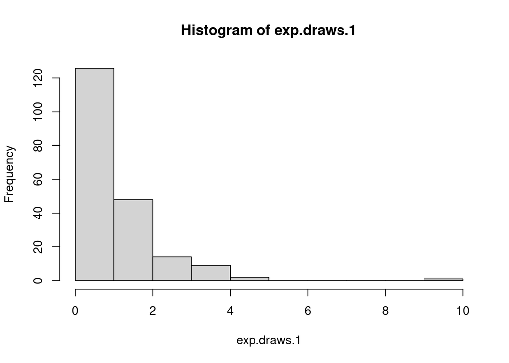

```r
hist(exp.draws.1)
```

b. Use `plot()` with this vector to display the random values from your standard distribution in order.

##### Solution

Type your answer here

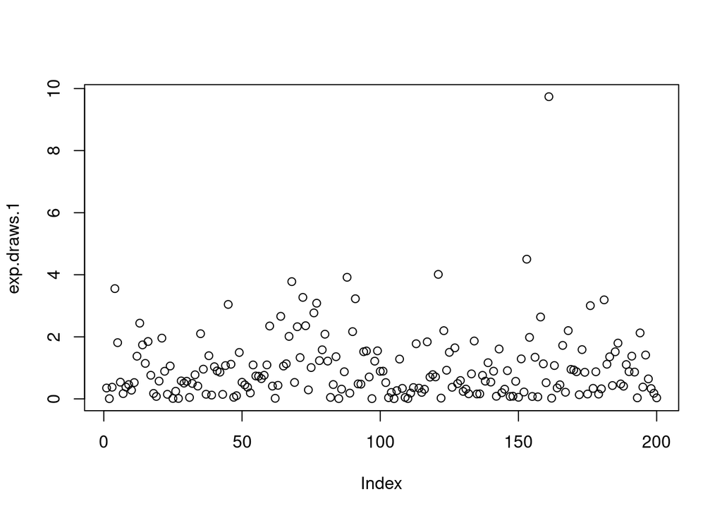

```r
plot(exp.draws.1)
```

c. Now, use `plot()` with two arguments – any two of your other stored random value vectors – to create a scatterplot of the two vectors against each other.

##### Solution

Type your answer here

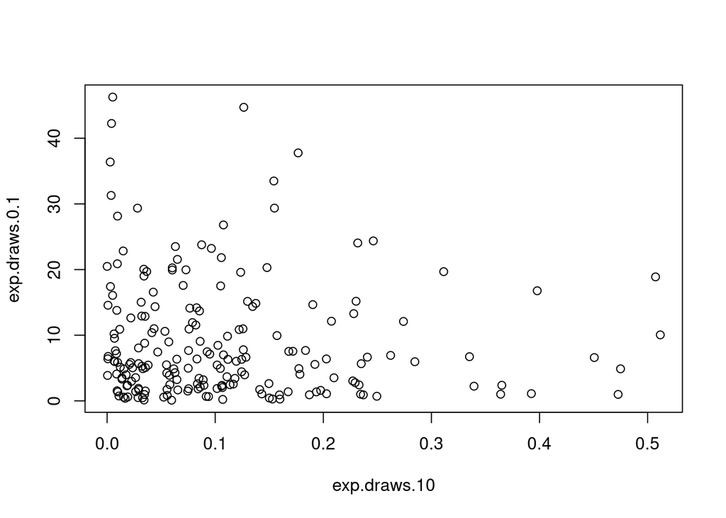

```r
plot(exp.draws.10, exp.draws.0.1)
```

##### Problem 4. (10 points)

We’d now like to compare the properties of each of our vectors. Begin by creating a vector of the means of each of our five distributions in the order we created them and saving this to a variable name of your choice. Using this and other similar vectors, create the following scatterplots: a. The five means versus the five rates used to generate the distribution.

##### Solution

Type your answer here

```r
MyVector = c(mean(exp.draws.1), mean(exp.draws.0.1), mean(exp.draws.0.5), mean(exp.draws.5), mean(exp.draws.10))

MyVector
```

```
## [1] 0.9951018 8.9985881 2.4748983 0.2001032 0.1076848
```

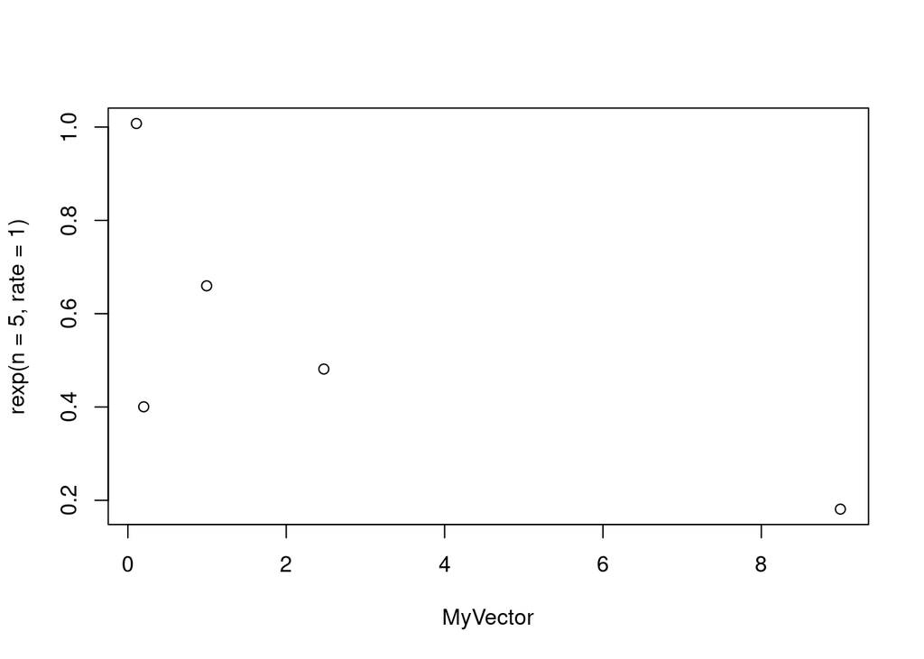

```r
plot(MyVector, rexp(n=5, rate=1))
```

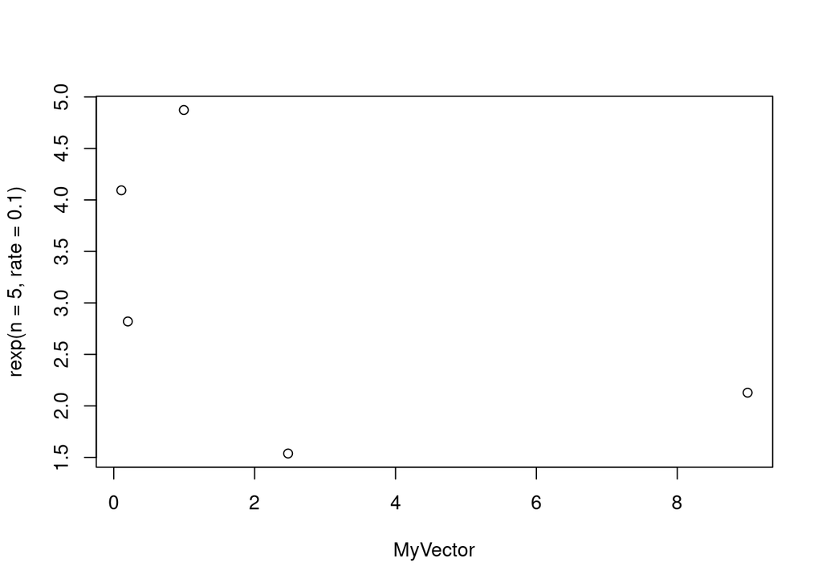

```r
plot(MyVector, rexp(n=5, rate=0.1))
```

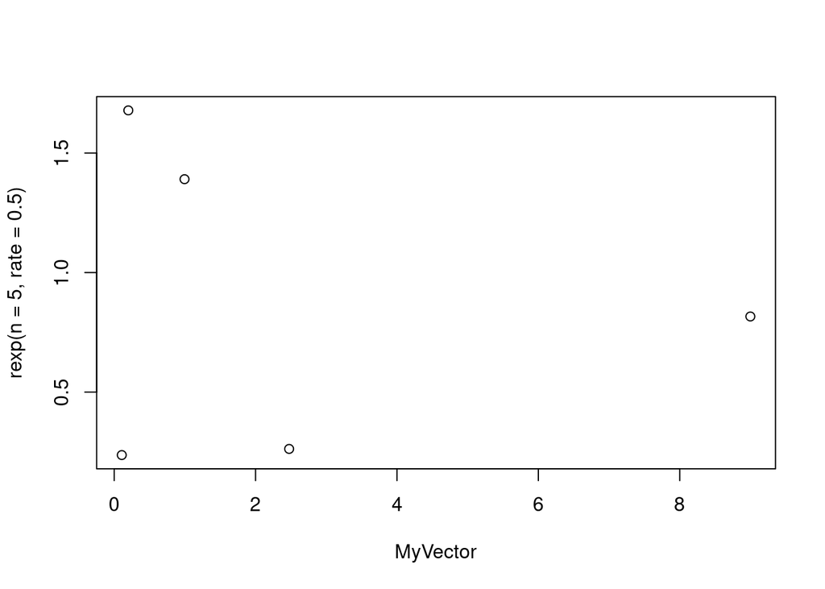

```r
plot(MyVector, rexp(n=5, rate=0.5))
```

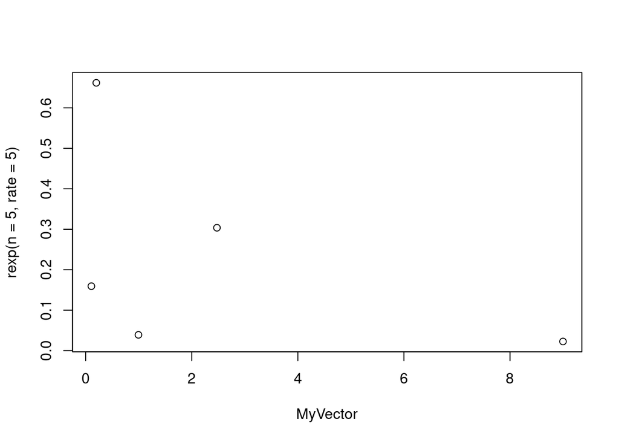

```r
plot(MyVector, rexp(n=5, rate=5))
```

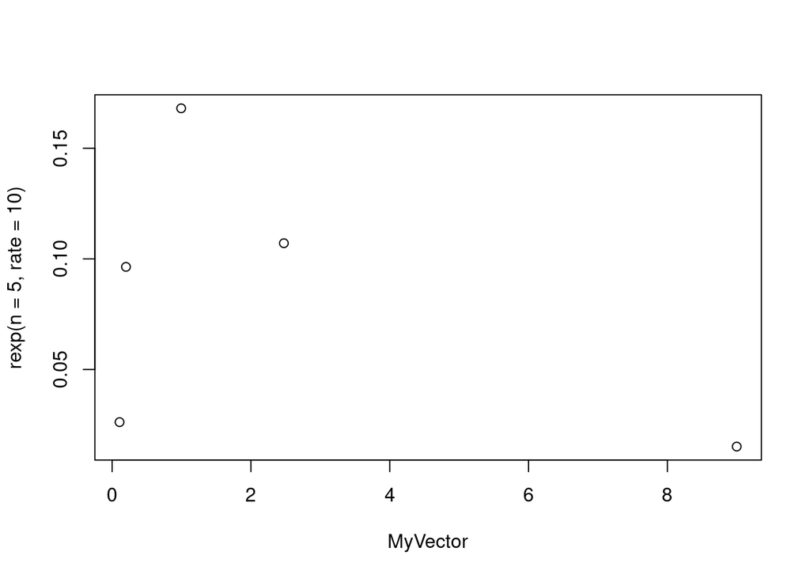

```r
plot(MyVector, rexp(n=5, rate=10))
```

b. The standard deviations versus the rates.

##### Solution

Type your answer here

```r
MyVectorSD = c(sd(exp.draws.1), sd(exp.draws.0.1), sd(exp.draws.0.5), sd(exp.draws.5), sd(exp.draws.10))

MyVectorSD
```

```
## [1] 1.0982275 9.0487202 2.3964927 0.1850706 0.1045797
```

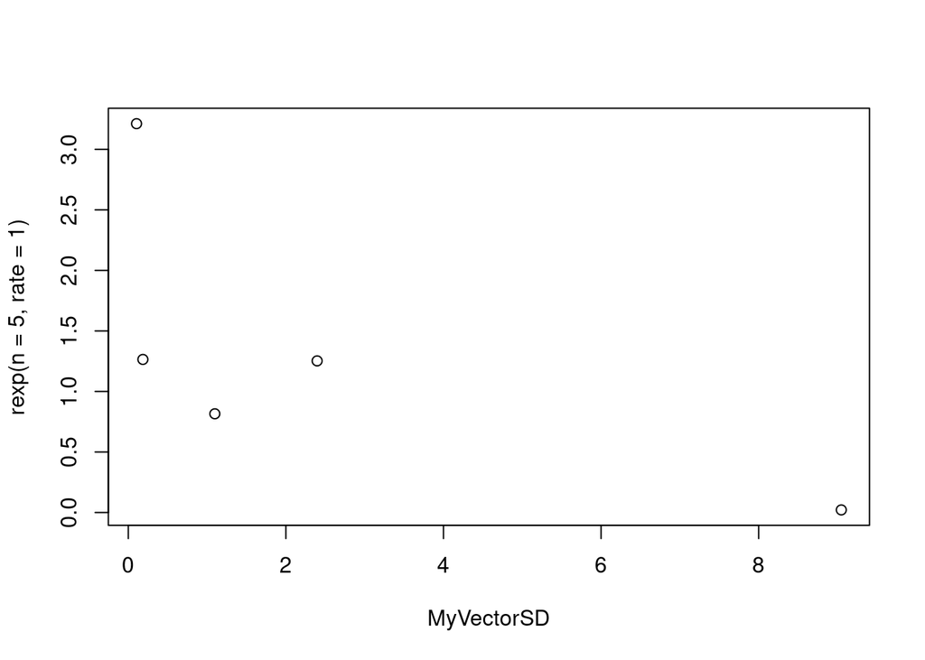

```r
plot(MyVectorSD, rexp(n=5, rate=1))
```

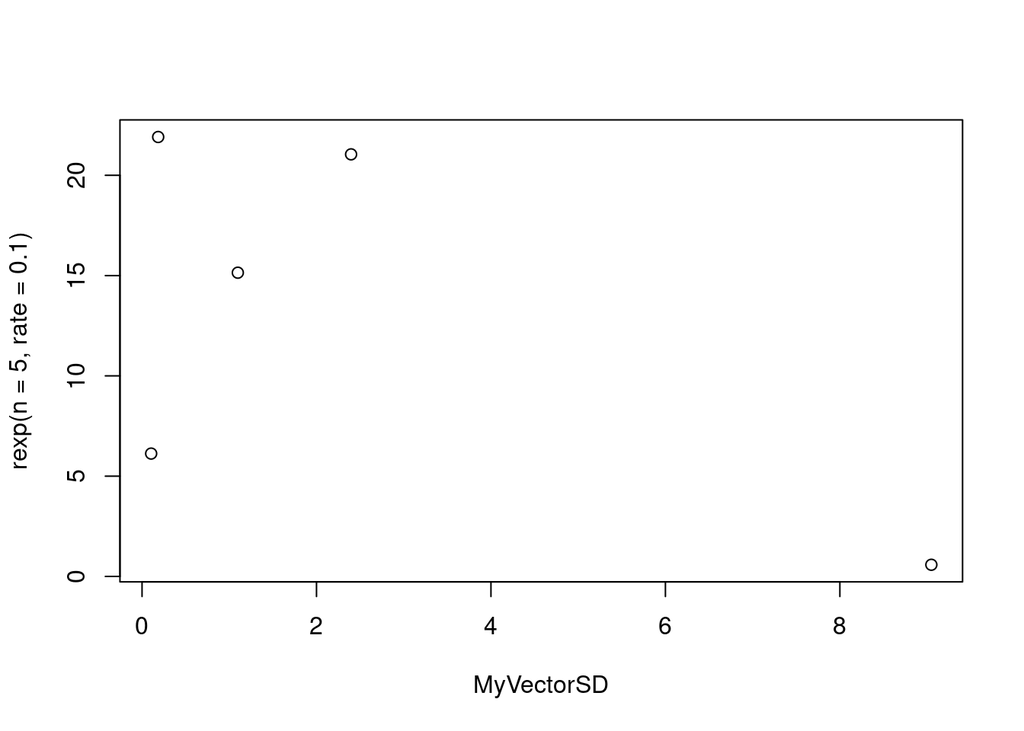

```r
plot(MyVectorSD, rexp(n=5, rate=0.1))
```

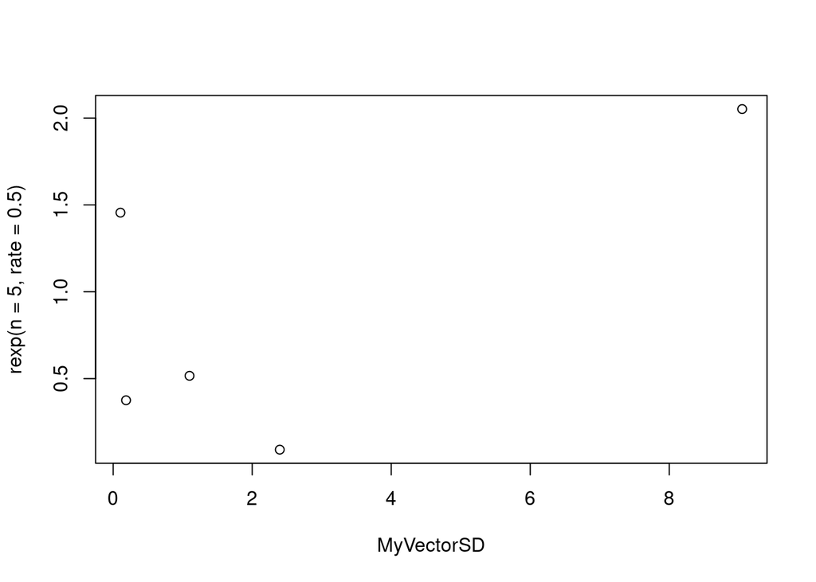

```r
plot(MyVectorSD, rexp(n=5, rate=0.5))
```

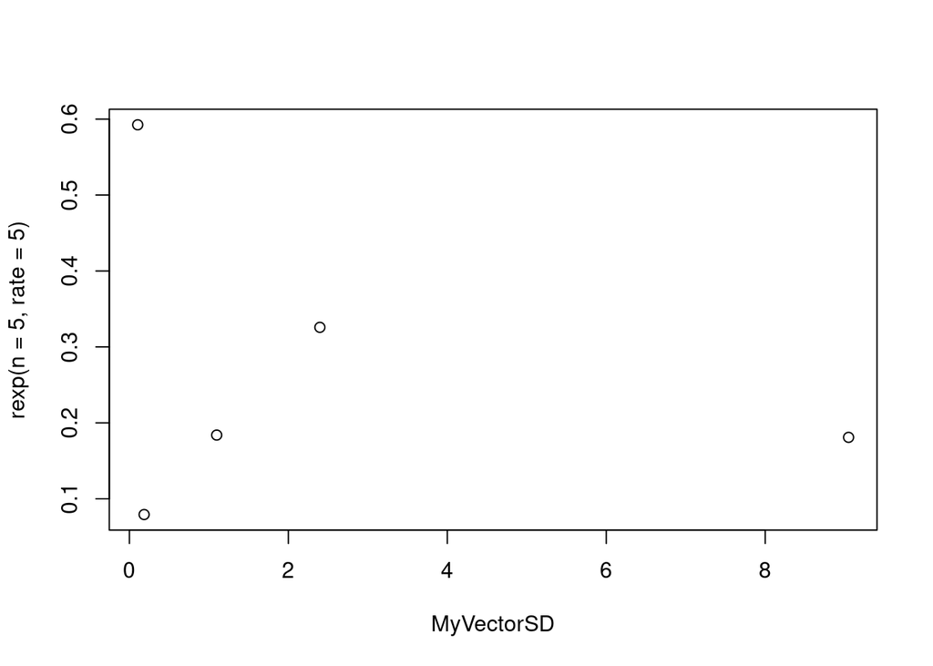

```r
plot(MyVectorSD, rexp(n=5, rate=5))
```

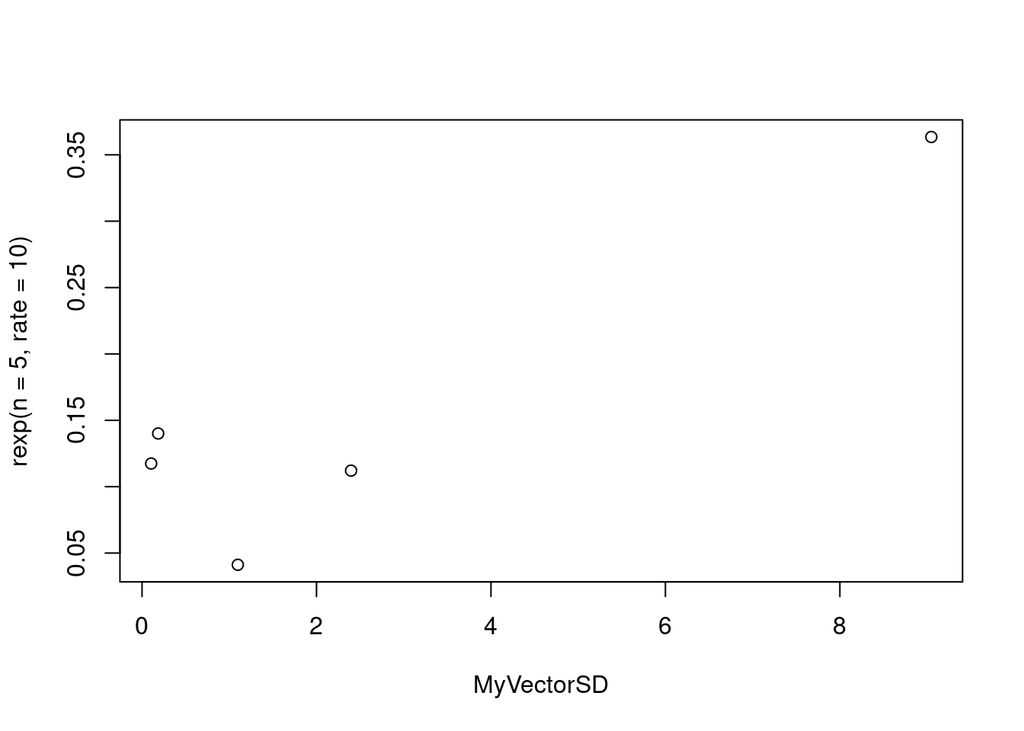

```r
plot(MyVectorSD, rexp(n=5, rate=10))
```

c. The means versus the standard deviations.

##### Solution

Type your answer here

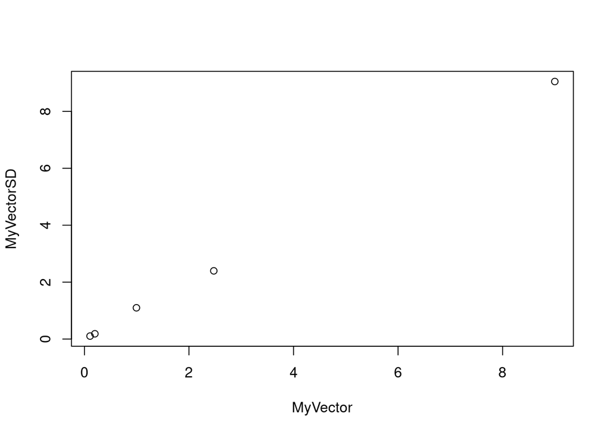

```r
plot(MyVector, MyVectorSD)
```

For each plot, explain in words what’s going on.

##### Solution

Type your answer here

## Part II

##### Problem 5. (10 points)

R’s capacity for data and computation is large to what was available 10 years ago. a. To show this, generate 1.1 million numbers from the standard exponential distribution and store them in a vector called `big.exp.draws.1`. Calculate the mean and standard deviation.

##### Solution

Type your answer here

```r
big.exp.draws.1 = rexp(n=1100000, rate=1)
mean(big.exp.draws.1)
```

```
## [1] 0.9984632
```

```r
sd(big.exp.draws.1)
```

```
## [1] 0.9980054
```

```
b. Plot a histogram of `big.exp.draws.1`.  Does it match the function $1-e^{-x}$?  Should it?
```

##### Solution

Type your answer here

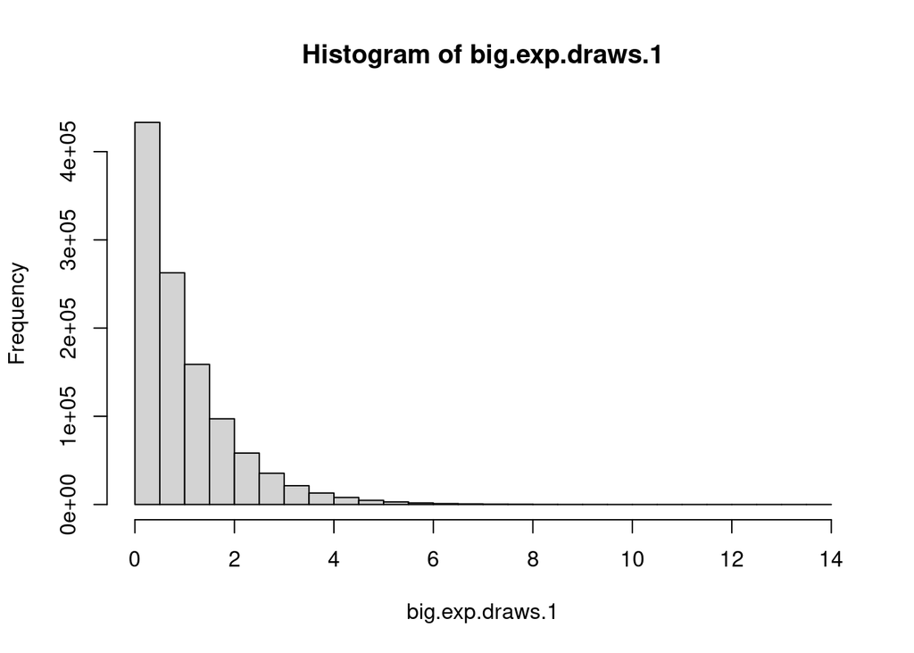

[output not shown]

```r
hist(big.exp.draws.1)
```

##### Solution

Type your answer here

```r
mean(big.exp.draws.1[big.exp.draws.1 > 1])
```

```
## [1] 1.997946
```

```
d. Create a matrix, `big.exp.draws.1.mat`, containing the the values in
```

`big.exp.draws.1`, with 1100 rows and 1000 columns. Use this matrix as the input to the `hist()` function and save the result to a variable of your choice. What happens to your data?

##### Solution

Type your answer here

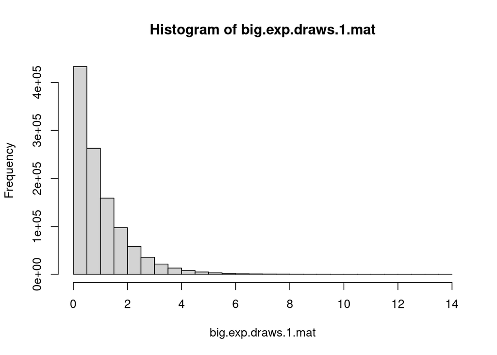

```r
big.exp.draws.1.mat = matrix(big.exp.draws.1, nrow = 1100, ncol = 1000)
mathist = hist(big.exp.draws.1.mat)
```

```r
mathist
```

```
## $breaks
##  [1]  0.0  0.5  1.0  1.5  2.0  2.5  3.0  3.5  4.0  4.5  5.0  5.5  6.0  6.5  7.0
## [16]  7.5  8.0  8.5  9.0  9.5 10.0 10.5 11.0 11.5 12.0 12.5 13.0 13.5 14.0
##
## $counts
##  [1] 433196 262673 158864  97171  58307  35413  21301  13002   7981   4732
## [11]   2932   1749   1010    672    388    250    136     86     59     31
## [21]     19     14      7      3      0      1      1      2
##
## $density
##  [1] 7.876291e-01 4.775873e-01 2.888436e-01 1.766745e-01 1.060127e-01
##  [6] 6.438727e-02 3.872909e-02 2.364000e-02 1.451091e-02 8.603636e-03
## [11] 5.330909e-03 3.180000e-03 1.836364e-03 1.221818e-03 7.054545e-04
## [16] 4.545455e-04 2.472727e-04 1.563636e-04 1.072727e-04 5.636364e-05
## [21] 3.454545e-05 2.545455e-05 1.272727e-05 5.454545e-06 0.000000e+00
## [26] 1.818182e-06 1.818182e-06 3.636364e-06
##
## $mids
##  [1]  0.25  0.75  1.25  1.75  2.25  2.75  3.25  3.75  4.25  4.75  5.25  5.75
## [13]  6.25  6.75  7.25  7.75  8.25  8.75  9.25  9.75 10.25 10.75 11.25 11.75
## [25] 12.25 12.75 13.25 13.75
##
## $xname
## [1] "big.exp.draws.1.mat"
##
## $equidist
## [1] TRUE
##
## attr(,"class")
## [1] "histogram"
```

the data seems to be the same as the hist of big.exp.draws.1 e. Calculate the mean of the 371st column of `big.exp.draws.1.mat`.

##### Solution

Type your answer here

```r
mean(big.exp.draws.1.mat[,371])
```

```
## [1] 1.058734
```

```
f. Now, find the means of all 1000 columns of `big.exp.draws.1.mat` simultaneously. Plot the histogram of column means.  Explain why its shape does not match the histogram in problem 5b).
```

##### Solution

Type your answer here

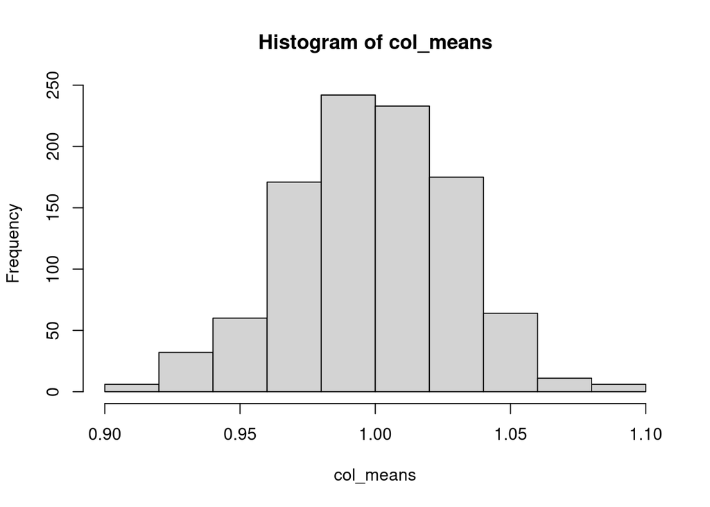

```r
col_means = colMeans(big.exp.draws.1.mat)
hist(col_means)
```

the shape is different because this is just the means of the columns.

```
g. Take the square of each number in `big.exp.draws.1`, and find the mean of this new vector.  Explain this in terms of the mean and standard deviation of `big.exp.draws.1`. ***Hint:*** think carefully about the formula R uses to calculate the standard deviation.
```

##### Solution

Type your answer here

```r
mean(sqrt(big.exp.draws.1))
```

```
## [1] 0.8856044
```

the mean of the square roots of big.exp.draws.1 are less then the mean and standard deviation of big.exp.draws.1. R calculates standard deciation with the equation sqrt((∑i=1n(xi−x¯)^2)/(n−1)).

##### Total Number of Points Earned: XX/50